# The Normal Distribution - Week 4

# The stepwise pattern may emerge with these distributions for sodium across a number of fast food chains because

# these restaurants typically offer an array of products (ie. french fries, soft drinks, sandwiches, salads) and the sodium content across these

# different food groups can vary quite a bit (ie. high in french fries or fried food and low in salads –> thus leading to different

# levels within the distribution.)

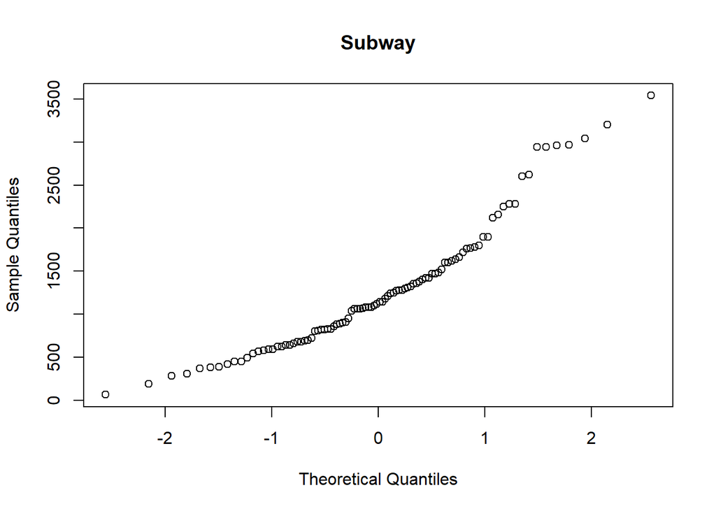

```r
#Subway sodium plot
sw <- fastfood %>%
  filter(restaurant == "Subway")

qqnorm(sw$sodium, main = "Subway")
```

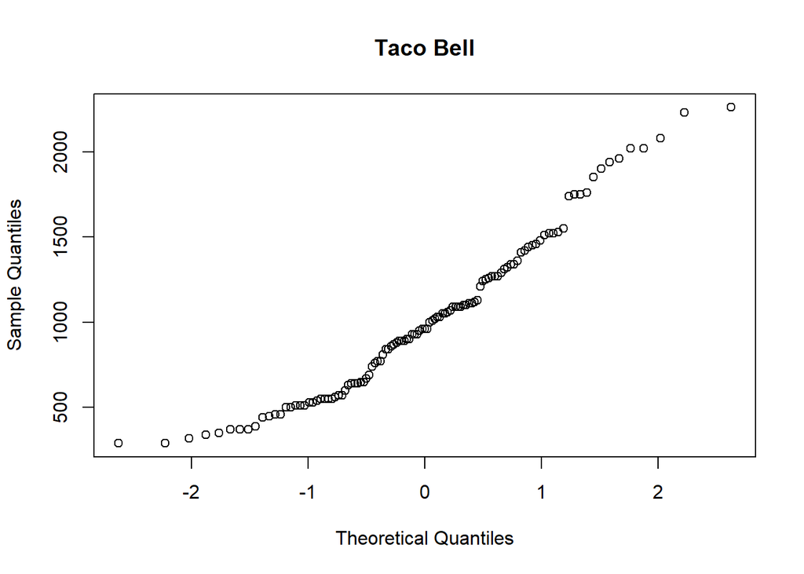

```r
#Taco Bell sodium plot
taco_bell <- fastfood %>%
  filter(restaurant == "Taco Bell")

qqnorm(taco_bell$sodium, main = "Taco Bell")
```

# Exercise 9: As you can see, normal probability plots can be used both to assess normality and visualize skewness.

# Make a normal probability plot for the total carbohydrates from a restaurant of your choice.

# Based on this normal probability plot, is this variable left skewed, symmetric, or right skewed?

# Use a histogram to confirm your findings.

# Based on the normal probability plot (below), this variable (total carbohydrates) is right skewed

and the histogram confirms this with data being concentrated on the left with a tail running to the right.

[figure not shown]

```r
#Normal plot for total carbohydrates from Dairy Queen
qqnorm(fastfood$total_carb, main = "Dairy Queen Carbs")
qqline(fastfood$total_carb)
```

```r
summary(fastfood$total_carb)
```

```
##    Min. 1st Qu.  Median    Mean 3rd Qu.    Max.
##    0.00   28.50   44.00   45.66   57.00  156.00
```

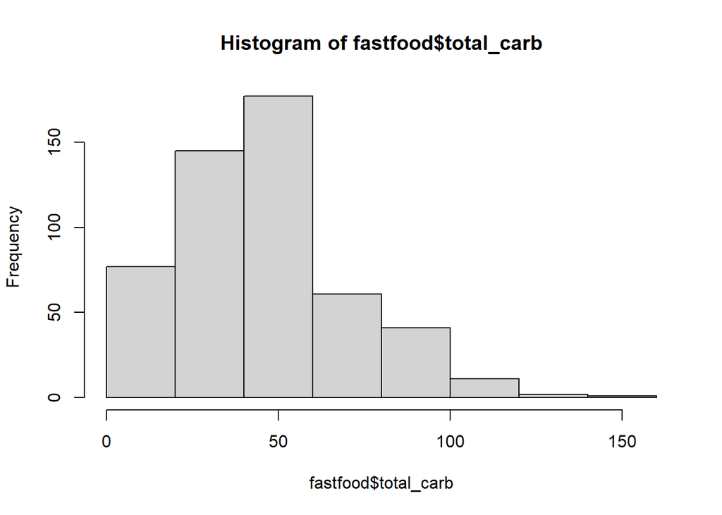

```r
hist(fastfood$total_carb)
```